# Data Science II Homework 5

Arghya Kannadaguli (ak5357)

2025-05-04

## **Problem 1.**

##### **In this problem, we will apply support vector machines to predict whether a given car gets high or low gas mileage based on the dataset “auto.csv” (used in Homework 3; see Homework 3 for more details of the dataset). The response variable is mpg cat. The predictors are cylinders, displacement, horsepower, weight, acceleration, year, and origin. Split the dataset into two parts: training data (70%) and test data (30%).**

```r
# Import data
auto = read_csv("data/auto.csv") |>
  mutate(mpg_cat = as.factor(mpg_cat))

# Split Data
set.seed(2025)
a.data.split = initial_split(auto, prop = 0.7)
a.train = training(a.data.split)
a.test = testing(a.data.split)
```

##### **(a) Fit a support vector classifier to the training data. What are the training and test error rates?**

**Fit SVM Classifier**

```r
# Train Control
set.seed(2025)
ctrl = trainControl(method = "cv")

# Fit SVM
set.seed(2025)
a.svm = train(mpg_cat ~ .,
               data = a.train,
               method = "svmLinear",
               tuneGrid = data.frame(C = exp(seq(-5, 2, len = 50))),
               trControl = ctrl)
```

**Visualize**

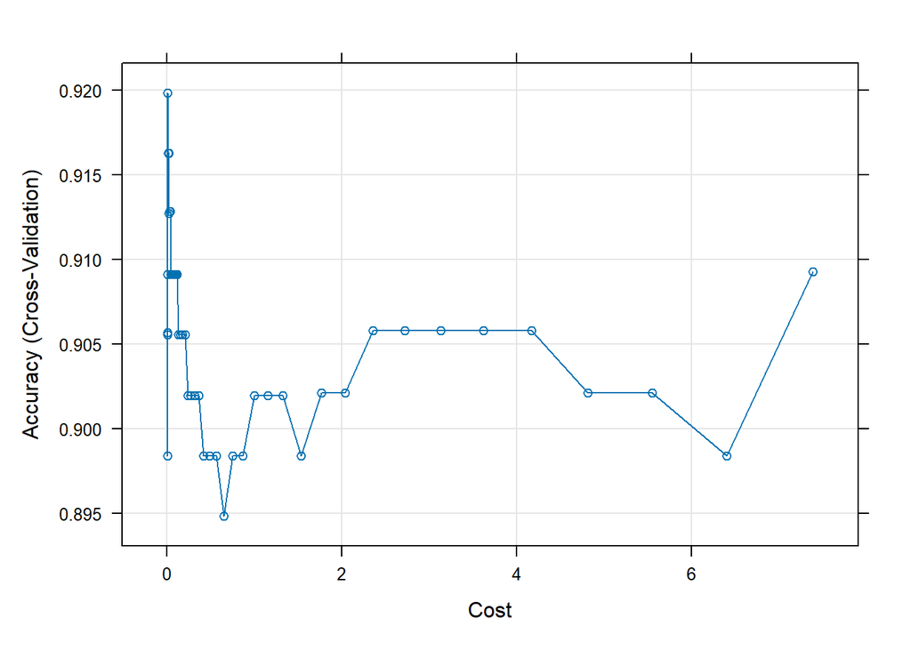

```r
# Visualize
plot(a.svm, highlight = TRUE)
```

**Training Error**

Based on the confusion matrix shown below, we can see that the model has an overall accuracy of 0.9234 on the training data, and therefore a 0.0766 error rate.

```r
# Predictions on Training Data
a.pred.train = predict(a.svm, newdata = a.train)

confusionMatrix(data = a.pred.train, reference = a.train$mpg_cat)
```

```
## Confusion Matrix and Statistics
##
##           Reference
## Prediction high low
##       high  137  17
##       low     4 116
##
##                Accuracy : 0.9234
##                  95% CI : (0.8852, 0.9519)
##     No Information Rate : 0.5146
##     P-Value [Acc > NIR] : < 2.2e-16
##
##                   Kappa : 0.8462
##
##  Mcnemar's Test P-Value : 0.008829
##
##             Sensitivity : 0.9716
##             Specificity : 0.8722
##          Pos Pred Value : 0.8896
##          Neg Pred Value : 0.9667
##              Prevalence : 0.5146
##          Detection Rate : 0.5000
##    Detection Prevalence : 0.5620
##       Balanced Accuracy : 0.9219
##
##        'Positive' Class : high
##
```

**Test Error**

```r
# Predictions on Training Data
a.pred.test = predict(a.svm, newdata = a.test)

confusionMatrix(data = a.pred.test, reference = a.test$mpg_cat)
```

```
## Confusion Matrix and Statistics
##
##           Reference
## Prediction high low
##       high   53  10
##       low     2  53
##
##                Accuracy : 0.8983
##                  95% CI : (0.8291, 0.9463)
##     No Information Rate : 0.5339
##     P-Value [Acc > NIR] : < 2e-16
##
##                   Kappa : 0.7975
##
##  Mcnemar's Test P-Value : 0.04331
##
##             Sensitivity : 0.9636
##             Specificity : 0.8413
##          Pos Pred Value : 0.8413
##          Neg Pred Value : 0.9636
##              Prevalence : 0.4661
##          Detection Rate : 0.4492
##    Detection Prevalence : 0.5339
##       Balanced Accuracy : 0.9025
##
##        'Positive' Class : high
##
```

##### **(b) Fit a support vector machine with a radial kernel to the training data. What are the training and test error rates?**

**Fit SVM with radial kernel**

```r
# Set tuning grid
svmr.grid = expand.grid(C = exp(seq(1, 7, len = 50)),
                        sigma = exp(seq(-10, -2, len = 20)))

# Fit SVM with Radial Kernel
set.seed(2025)
a.svm.rad = train(mpg_cat ~ .,
               data = a.train,
               method = "svmRadialSigma",
               tuneGrid = svmr.grid,
               trControl = ctrl)
```

**Visualize**

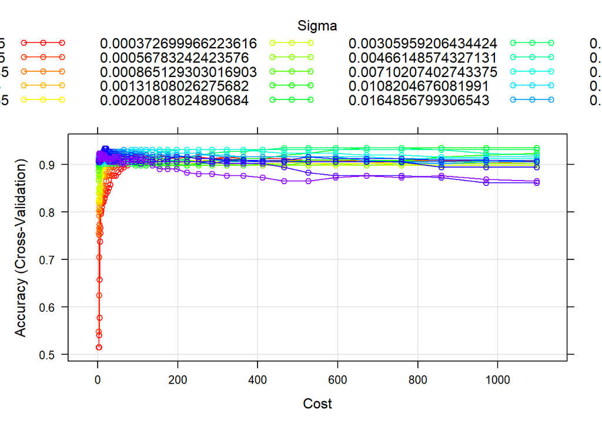

```r
# Visualize
myCol = rainbow(25)
myPar = list(superpose.symbol = list(col = myCol),
  superpose.line = list(col = myCol))

plot(a.svm.rad, highlight = TRUE, par.settings = myPar)
```

**Training Error**

Based on the confusion matrix shown below, we can see that the model has an overall accuracy of 0.9416 on the training data, and therefore a 0.0584 error rate.

```r
# Predictions on Training Data
a.pred.rad.train = predict(a.svm.rad, newdata = a.train)

confusionMatrix(data = a.pred.rad.train, reference = a.train$mpg_cat)
```

```
## Confusion Matrix and Statistics
##
##           Reference
## Prediction high low
##       high  136  11
##       low     5 122
##
##                Accuracy : 0.9416
##                  95% CI : (0.9069, 0.9663)
##     No Information Rate : 0.5146
##     P-Value [Acc > NIR] : <2e-16
##
##                   Kappa : 0.883
##
##  Mcnemar's Test P-Value : 0.2113
##
##             Sensitivity : 0.9645
##             Specificity : 0.9173
##          Pos Pred Value : 0.9252
##          Neg Pred Value : 0.9606
##              Prevalence : 0.5146
##          Detection Rate : 0.4964
##    Detection Prevalence : 0.5365
##       Balanced Accuracy : 0.9409
##
##        'Positive' Class : high
##
```

**Test Error**

```r
# Predictions on Training Data
a.pred.rad.test = predict(a.svm.rad, newdata = a.test)

confusionMatrix(data = a.pred.rad.test, reference = a.test$mpg_cat)
```

```
## Confusion Matrix and Statistics
##
##           Reference
## Prediction high low
##       high   51   8
##       low     4  55
##
##                Accuracy : 0.8983
##                  95% CI : (0.8291, 0.9463)
##     No Information Rate : 0.5339
##     P-Value [Acc > NIR] : <2e-16
##
##                   Kappa : 0.7966
##
##  Mcnemar's Test P-Value : 0.3865
##
##             Sensitivity : 0.9273
##             Specificity : 0.8730
##          Pos Pred Value : 0.8644
##          Neg Pred Value : 0.9322
##              Prevalence : 0.4661
##          Detection Rate : 0.4322
##    Detection Prevalence : 0.5000
##       Balanced Accuracy : 0.9001
##
##        'Positive' Class : high
##
```

## **Problem 2.**

##### **In this problem, we perform hierarchical clustering on the states using the USArrests data in the ISLR package. For each of the 50 states in the United States, the dataset contains the number of arrests per 100,000 residents for each of three crimes: Assault, Murder, and Rape. The dataset also contains the percent of the population in each state living in urban areas, UrbanPop. The four variables will be used as features for clustering.**

```r
data("USArrests")
usarrests = USArrests
rm(USArrests)

head(usarrests)
```

|  | Murder | Assault | UrbanPop | Rape |
| --- | --- | --- | --- | --- |
| Alabama | 13.2 | 236 | 58 | 21.2 |
| Alaska | 10.0 | 263 | 48 | 44.5 |
| Arizona | 8.1 | 294 | 80 | 31.0 |
| Arkansas | 8.8 | 190 | 50 | 19.5 |
| California | 9.0 | 276 | 91 | 40.6 |
| Colorado | 7.9 | 204 | 78 | 38.7 |

##### **(a) Using hierarchical clustering with complete linkage and Euclidean distance, cluster the states. Cut the dendrogram at a height that results in three distinct clusters. Which states belong to which clusters?**

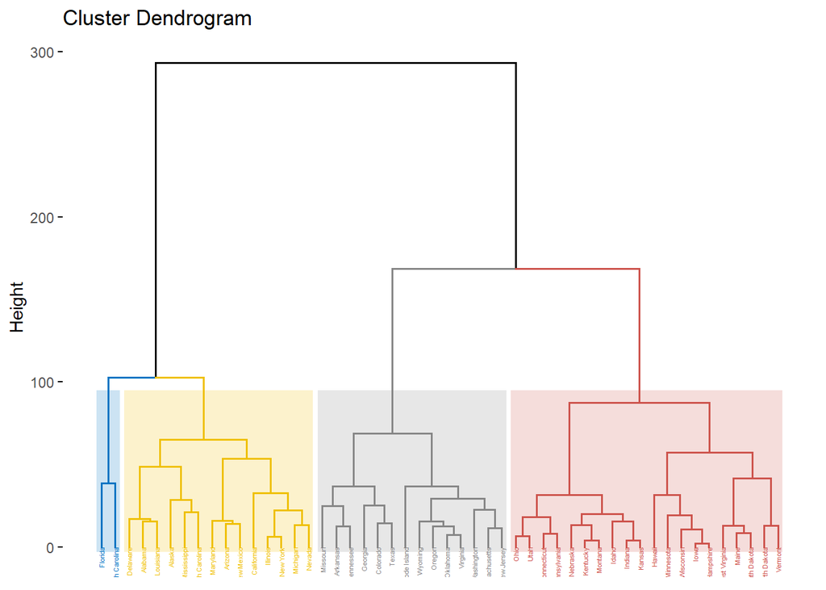

```r
# Hierarchical Clusters
hc.complete = hclust(dist(usarrests), method = "complete")

# Visualize
fviz_dend(hc.complete, k = 4,
          cex = 0.3,
          palette = "jco", # color scheme; other palettes:"npg","aaas"...
          color_labels_by_k = TRUE,
          rect = TRUE, # whether to add a rectangle around groups.
          rect_fill = TRUE,
          rect_border = "jco",
          labels_track_height = 2.5)
```

**States by Cluster**

```r
hc.3 = cutree(hc.complete, 3)
#   as.data.frame() |>
#   rownames_to_column()
# names(hc.3) = c("state", "cluster")
```

**Cluster 1**

```r
usarrests[hc.3 == 1,] |>
  rownames_to_column() |>
  rename(state = rowname) |>
  gt() |>
  fmt_number(columns = c(state, Murder, Assault, UrbanPop, Rape), decimals = 1) |>
  tab_style(
    style = cell_text(weight = "bold"),
    locations = cells_column_labels(everything())) |>
  tab_header(
    title = "Cluster 1 States") |>
  cols_label(
    state = "State",
    Murder = "Murder",
    Assault = "Assault",
    UrbanPop = "Urban Population (%)",
    Rape = "Rape") |>
  tab_options(
    table.font.size = "small",
    heading.align = "center")
```

Cluster 1 States

| State | Murder | Assault | Urban Population (%) | Rape |
| --- | --- | --- | --- | --- |
| Alabama | 13.2 | 236.0 | 58.0 | 21.2 |
| Alaska | 10.0 | 263.0 | 48.0 | 44.5 |
| Arizona | 8.1 | 294.0 | 80.0 | 31.0 |
| California | 9.0 | 276.0 | 91.0 | 40.6 |
| Delaware | 5.9 | 238.0 | 72.0 | 15.8 |
| Florida | 15.4 | 335.0 | 80.0 | 31.9 |
| Illinois | 10.4 | 249.0 | 83.0 | 24.0 |
| Louisiana | 15.4 | 249.0 | 66.0 | 22.2 |
| Maryland | 11.3 | 300.0 | 67.0 | 27.8 |
| Michigan | 12.1 | 255.0 | 74.0 | 35.1 |
| Mississippi | 16.1 | 259.0 | 44.0 | 17.1 |
| Nevada | 12.2 | 252.0 | 81.0 | 46.0 |
| New Mexico | 11.4 | 285.0 | 70.0 | 32.1 |
| New York | 11.1 | 254.0 | 86.0 | 26.1 |
| North Carolina | 13.0 | 337.0 | 45.0 | 16.1 |
| South Carolina | 14.4 | 279.0 | 48.0 | 22.5 |

**Cluster 2**

```r
usarrests[hc.3 == 2,] |>
  rownames_to_column() |>
  rename(state = rowname) |>
  gt() |>
  fmt_number(columns = c(state, Murder, Assault, UrbanPop, Rape), decimals = 1) |>
  tab_style(
    style = cell_text(weight = "bold"),
    locations = cells_column_labels(everything())) |>
  tab_header(
    title = "Cluster 1 States") |>
  cols_label(
    state = "State",
    Murder = "Murder",
    Assault = "Assault",
    UrbanPop = "Urban Population (%)",
    Rape = "Rape") |>
  tab_options(
    table.font.size = "small",
    heading.align = "center")
```

| State | Murder | Assault | Urban Population (%) | Rape |
| --- | --- | --- | --- | --- |
| Arkansas | 8.8 | 190.0 | 50.0 | 19.5 |
| Colorado | 7.9 | 204.0 | 78.0 | 38.7 |
| Georgia | 17.4 | 211.0 | 60.0 | 25.8 |
| Massachusetts | 4.4 | 149.0 | 85.0 | 16.3 |
| Missouri | 9.0 | 178.0 | 70.0 | 28.2 |
| New Jersey | 7.4 | 159.0 | 89.0 | 18.8 |
| Oklahoma | 6.6 | 151.0 | 68.0 | 20.0 |
| Oregon | 4.9 | 159.0 | 67.0 | 29.3 |
| Rhode Island | 3.4 | 174.0 | 87.0 | 8.3 |
| Tennessee | 13.2 | 188.0 | 59.0 | 26.9 |
| Texas | 12.7 | 201.0 | 80.0 | 25.5 |
| Virginia | 8.5 | 156.0 | 63.0 | 20.7 |
| Washington | 4.0 | 145.0 | 73.0 | 26.2 |
| Wyoming | 6.8 | 161.0 | 60.0 | 15.6 |

**Cluster 3**

```r
usarrests[hc.3 == 3,] |>
  rownames_to_column() |>
  rename(state = rowname) |>
  gt() |>
  fmt_number(columns = c(state, Murder, Assault, UrbanPop, Rape), decimals = 1) |>
  tab_style(
    style = cell_text(weight = "bold"),
    locations = cells_column_labels(everything())) |>
  tab_header(
    title = "Cluster 1 States") |>
  cols_label(
    state = "State",
    Murder = "Murder",
    Assault = "Assault",
    UrbanPop = "Urban Population (%)",
    Rape = "Rape") |>
  tab_options(
    table.font.size = "small",
    heading.align = "center")
```

| State | Murder | Assault | Urban Population (%) | Rape |
| --- | --- | --- | --- | --- |
| Connecticut | 3.3 | 110.0 | 77.0 | 11.1 |
| Hawaii | 5.3 | 46.0 | 83.0 | 20.2 |
| Idaho | 2.6 | 120.0 | 54.0 | 14.2 |
| Indiana | 7.2 | 113.0 | 65.0 | 21.0 |
| Iowa | 2.2 | 56.0 | 57.0 | 11.3 |
| Kansas | 6.0 | 115.0 | 66.0 | 18.0 |
| Kentucky | 9.7 | 109.0 | 52.0 | 16.3 |
| Maine | 2.1 | 83.0 | 51.0 | 7.8 |
| Minnesota | 2.7 | 72.0 | 66.0 | 14.9 |
| Montana | 6.0 | 109.0 | 53.0 | 16.4 |
| Nebraska | 4.3 | 102.0 | 62.0 | 16.5 |
| New Hampshire | 2.1 | 57.0 | 56.0 | 9.5 |
| North Dakota | 0.8 | 45.0 | 44.0 | 7.3 |
| Ohio | 7.3 | 120.0 | 75.0 | 21.4 |
| Pennsylvania | 6.3 | 106.0 | 72.0 | 14.9 |
| South Dakota | 3.8 | 86.0 | 45.0 | 12.8 |
| Utah | 3.2 | 120.0 | 80.0 | 22.9 |
| Vermont | 2.2 | 48.0 | 32.0 | 11.2 |
| West Virginia | 5.7 | 81.0 | 39.0 | 9.3 |
| Wisconsin | 2.6 | 53.0 | 66.0 | 10.8 |

##### **(b) Hierarchically cluster the states using complete linkage and Euclidean distance, after scaling the variables to have standard deviation one. Does scaling the variables change the clustering results? In your opinion, should the variables be scaled before the inter-observation dissimilarities are computed?**

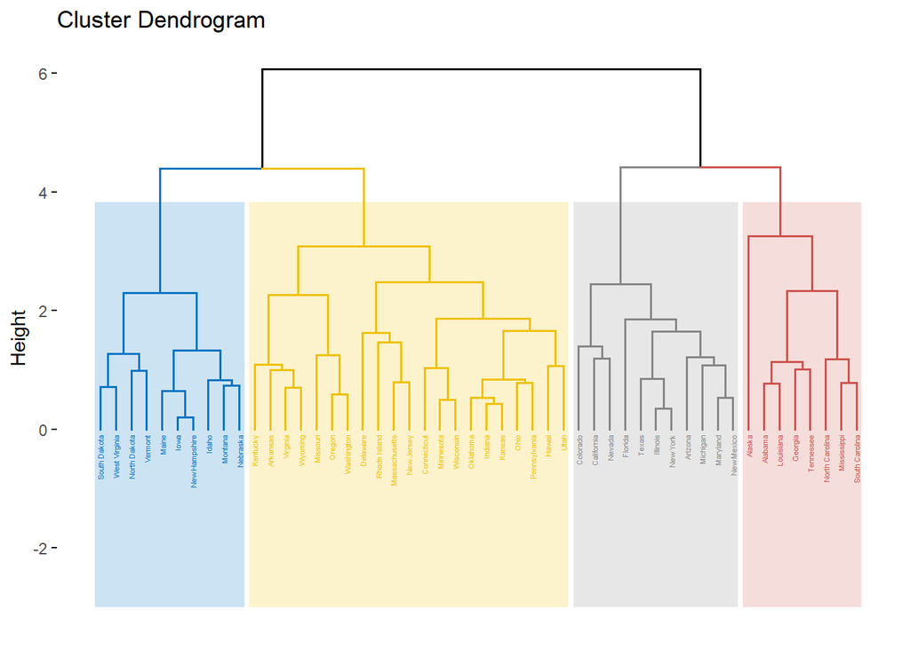

```r
us.scaled = usarrests
us.scaled$Murder = (us.scaled$Murder)/sd(us.scaled$Murder)
us.scaled$Assault = (us.scaled$Assault)/sd(us.scaled$Assault)
us.scaled$UrbanPop = (us.scaled$UrbanPop)/sd(us.scaled$UrbanPop)
us.scaled$Rape = (us.scaled$Rape)/sd(us.scaled$Rape)

# us.scaled = usarrests |>
#   mutate(across(everything(), scale))

# Hierarchical Clusters
hc.scaled = hclust(dist(us.scaled), method = "complete")

# Visualize
fviz_dend(hc.scaled, k = 4,
          cex = 0.3,
          palette = "jco", # color scheme; other palettes:"npg","aaas"...
          color_labels_by_k = TRUE,
          rect = TRUE, # whether to add a rectangle around groups.
          rect_fill = TRUE,
          rect_border = "jco",
          labels_track_height = 2.5)
```

**Does scaling the variables change the clustering results?**

Many states have have changed substantially after the data was scaled by standard deviation. The height of the dendrogram has also changed from ~300 to ~6. This is likely because the relative “positions” of the data points as plotted in a 4-d space (4 variables) have changed once the values were scaled, so that would influence calculations of Euclidean distance.

**In your opinion, should the variables be scaled before the inter-observation dissimilarities are computed?**

Yes, variables should be scaled before the Euclidean distances are computed to remove the influence of variables’ units on the splitting of clusters. Scaling for distance-based algorithms is important because without normalizing by SD, Euclidean distances are influenced not only by variance in the data, but also by each variable’s units, leading to a result that may not reflect true patterns. Variables with larger scales/variances would disproportionately influence clusters.

```r
hc.sc.3 = cutree(hc.scaled, 3)
hc.sc.3
```

```
##        Alabama         Alaska        Arizona       Arkansas     California
##              1              1              2              3              2
##       Colorado    Connecticut       Delaware        Florida        Georgia
##              2              3              3              2              1
##         Hawaii          Idaho       Illinois        Indiana           Iowa
##              3              3              2              3              3
##         Kansas       Kentucky      Louisiana          Maine       Maryland
##              3              3              1              3              2
##  Massachusetts       Michigan      Minnesota    Mississippi       Missouri
##              3              2              3              1              3
##        Montana       Nebraska         Nevada  New Hampshire     New Jersey
##              3              3              2              3              3
##     New Mexico       New York North Carolina   North Dakota           Ohio
##              2              2              1              3              3
##       Oklahoma         Oregon   Pennsylvania   Rhode Island South Carolina
##              3              3              3              3              1
##   South Dakota      Tennessee          Texas           Utah        Vermont
##              3              1              2              3              3
##       Virginia     Washington  West Virginia      Wisconsin        Wyoming
##              3              3              3              3              3
```

Adding cluster membership to usarrests data for visualizations.

```r
# Add cluster membership to usarrests df
us.dat = usarrests |>
  rownames_to_column() |>
  janitor::clean_names() |>
  rename(state = rowname)

us.dat$hc = hc.3
us.dat$hc_sc = hc.sc.3
```

How many states have changed cluster membership?

```r
us.dat |>
  count(hc != hc_sc)
```

| hc != hc_sc | n |
| --- | --- |
| FALSE | 28 |
| TRUE | 22 |

To visualize the difference in clusters, here’s a map. Alaska and Hawaii do not change clusters, so they have not been included in this map.

```r
# Get states from tigris
states_sf = states(cb = TRUE, resolution = "20m", year = 2020) |>
  st_transform(4326) |>
  inner_join(us.dat, by = c("NAME" = "state"))
```

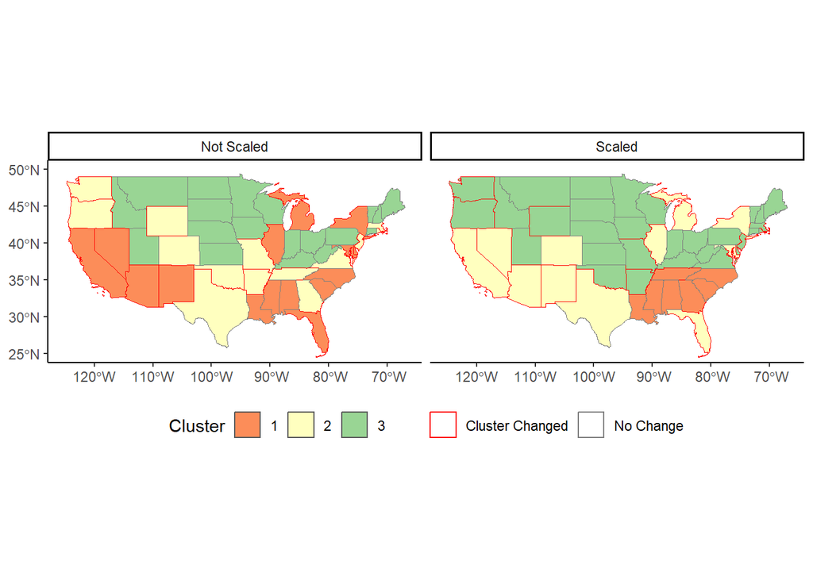

```r
# Map
states_sf |>
  mutate(change = ifelse(hc == hc_sc, "No Change", "Cluster Changed")) |>
  pivot_longer(
    cols = c(hc, hc_sc),
    names_to = "scale",
    values_to = "cluster"
  ) |>
  mutate(scale = ifelse(scale == "hc", "Not Scaled", "Scaled")) |>
  ggplot() +
  geom_sf(aes(fill = as.factor(cluster))) +
  geom_sf(aes(color = as.factor(change)), fill = "NA") +
  scale_fill_brewer(palette = "Spectral") +
  scale_color_manual(values = c("No Change" = NA, "Cluster Changed" = "red")) +
  facet_wrap(~ scale) +
  labs(fill = "Cluster", color = "") +
  xlim(c(-125, -67)) +
  ylim(c(25, 50)) +
  theme(legend.position = "bottom")
```